# Data Visualiation

Lynda Boothroyd, based on a tutorial by Lisa DeBruine

30/08/2019

Alongside its uses in data wrangling, the other big strength of the Tidyverse is *ggplot2* - henceforth refered to as GGPlot. *GGPlot* is a powerful visualiation tool which lets researchers plot data in a wide variety of formats. Not only does it cover al lthe traditional format plots, but it can be used to combine plots on the same axis, as well as building plots which can be used in interactive formats such as simple data-point labelling (see *Plotly* below) or fully interactive plotting apps through *Shiny* applications. In this session, we create some artificial datasets and then try out all the main methods for plotting them.

## Resources

- [Data Visualisation](https://psyteachr.github.io/msc-data-skills/ggplot.html) in Data Skills for Reproducible Science
- [Data Visualisation Cheatsheet](https://github.com/rstudio/cheatsheets/raw/master/data-visualization-2.1.pdf)
- Stub script for this lesson

The code below creates a few data files for our examples. (Data simulation is a lesson for another day, but a chapter on it can be found [here] (https://psyteachr.github.io/msc-data-skills/sim.html).

```r
set.seed(1000)

pets <- tibble(
  pet = sample(
    c("dog", "cat", "ferret", "bird", "fish"),
    100,
    TRUE,
    c(0.45, 0.40, 0.05, 0.05, 0.05)
  )
)

pet_happy <- tibble(
  pet = rep(c("dog", "cat"), each = 500),
  happiness = c(rnorm(500, 55, 10), rnorm(500, 45, 10)),
  age = rpois(1000, 3) + 20
)

x_vs_y <- tibble(
  x = rnorm(100),
  y = x + rnorm(100, 0, 0.5)
)

overlap <- tibble(
  x = rbinom(1000, 10, 0.5),
  y = x + rbinom(1000, 20, 0.5)
)

overplot <- tibble(
  x = rnorm(10000),
  y = x + rnorm(10000, 0, 0.5)
)
```

# GGPlot intro

*GGPlot* builds figures in layers based on dataframes. We can tell it what dataframe to use and then add in visual components called geoms, and assign variables to the plot using ‘aesthetics’, coded **aes**.

Each **aes** function tells *GGPlot* which variables you want to represent and, if applicable, what aspects of the plot will represent that variable (axes, line type, colour, etc).

Each geom is a visual representation of the data as specified in the aesthetics. Although we can sets visual properties to represent variables (e.g. represnt a categorical variable by colour), we can also set colours etc for geoms without, or over-riding, any variable properties set in aesthetics elsewhere.

## geom_bar() (plus removing legends adding themes)

Bar plots represent counts of data. Using the pets dataset simulated above, we can plot how many cases there are of each type of pet. We first need to tell *ggplot* to use ‘pets’ and to assign the variable pet to the x axis. This inititually produces an empty plot. Then can then add a layer with **geom_bar** to show the frequencies of each pet. In the second plot below we add bar properties, and remove the legend.

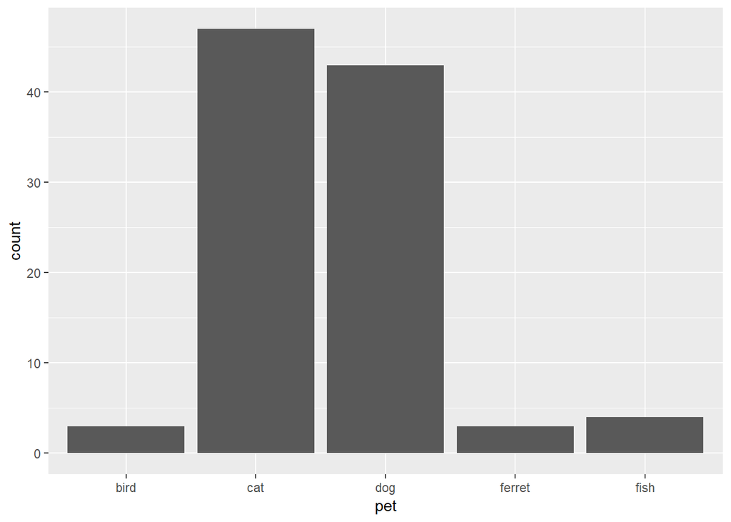

```r
#We tell ggplot to use dataframe pets, to represent pet on the x axis, and then we add a layer in which a bar chart is used.
ggplot(pets, aes(x=pet))  + geom_bar( )
```

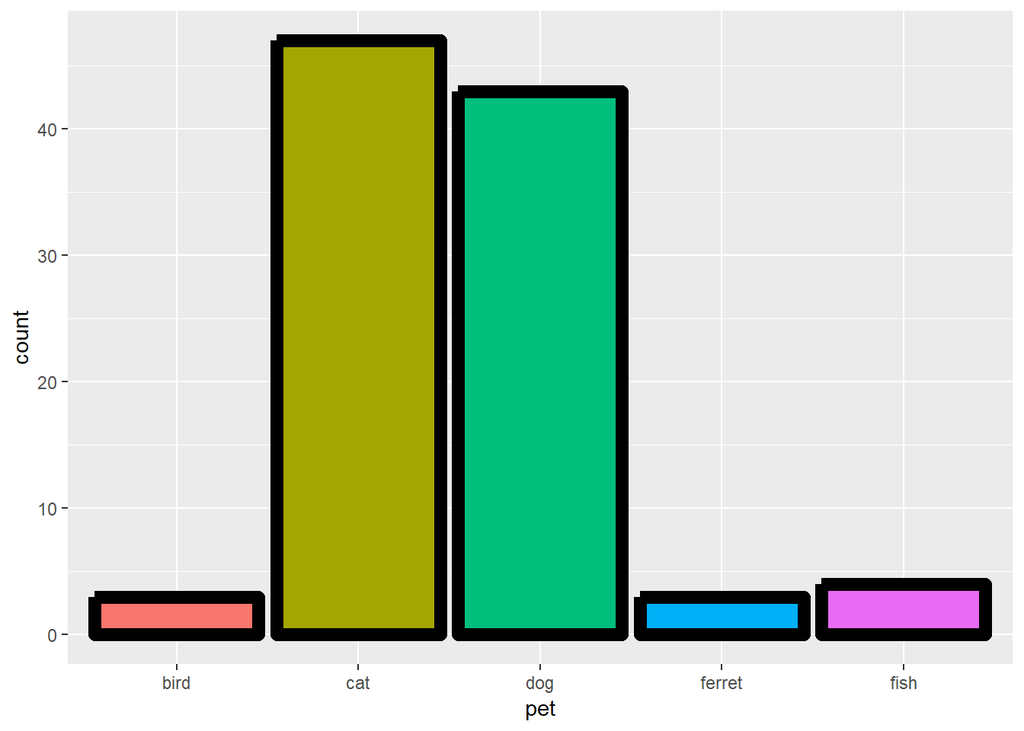

```r
#Now, we tell it to fill the bars with colours based on the variable pet.
#Within the bar geom, we tell it to make the outline black, and the bars size '3'.
#We specify to drop the fill legend for the bars because they're given on the x axis
ggplot(pets, aes(x=pet, fill=pet))  + geom_bar( color = "black", size=3, show.legend = F)
```

Note, *GGPlot* has a default ‘theme’ which gives the exaes and plot background a particular appearance. We can add an alternative theme to a plot, as below. These themes are built into *GGPlot*, but additional commands can be included in the text adding the theme, if we want to change the defaults of that theme.

If we want to set a default theme within a document, we can use **theme_set** function before we start making our figures.

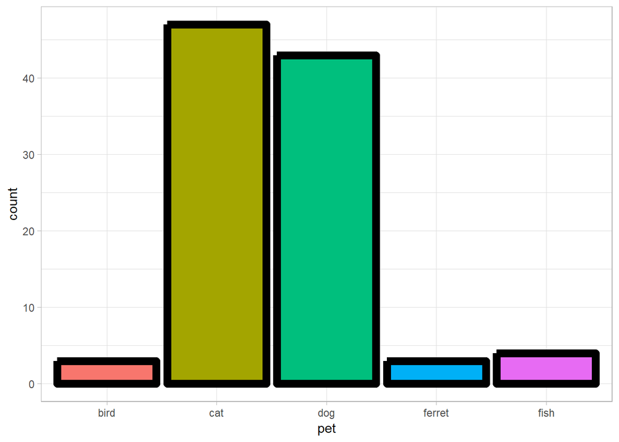

```r
ggplot(pets, aes(x=pet, fill=pet))  + geom_bar( color = "black", size=3, show.legend = F) + theme_light()
```

```r
theme_set(theme_minimal()) #I've now set minimal, which will be how the rest of the figures below look.
```

## geom_histogram()

Histograms show frequencies of values (rather than categories in bar plots above). The first plot shows how *GGPlot* creates a histogram using defaults. However, it’s often necessary to adjust the properties, especially bin width (how many values each bar represents), to get a nice looking plot.

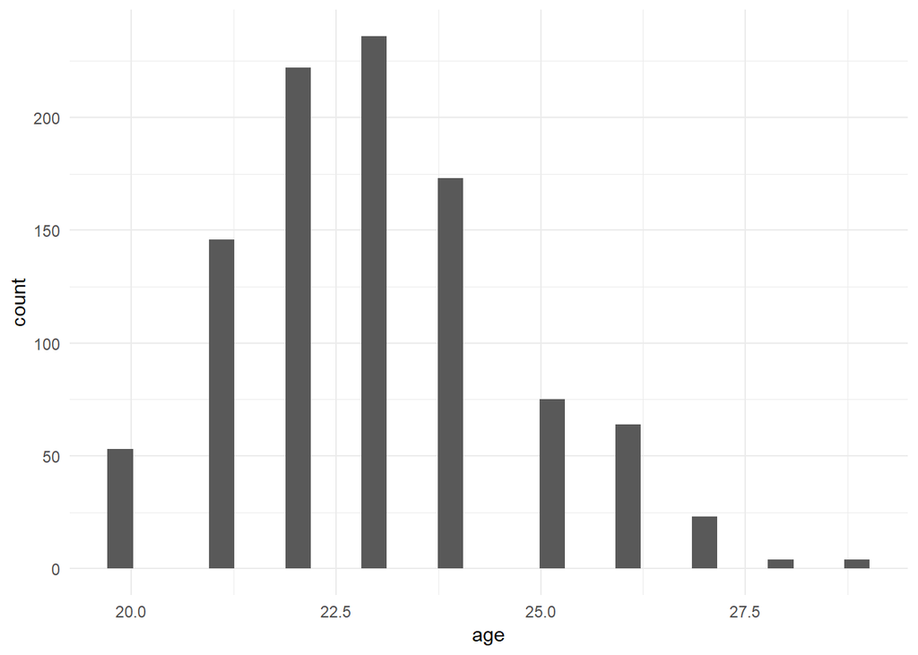

```r
#First we tell ggplot to use dataframe pet_happy, put age on the x axis, and then to add a layer which is a histogram
ggplot(pet_happy, aes(x = age)) + geom_histogram()
```

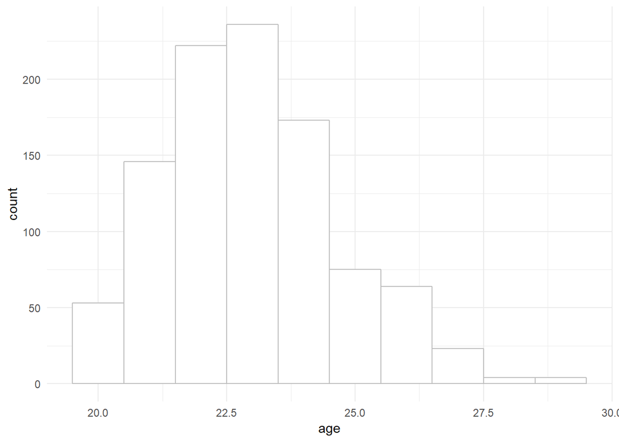

```r
#Now we specify binwidth (1 unit (year) each) and tell it to make the bars white with grey eding, so it looks better.
ggplot(pet_happy, aes(x = age)) + geom_histogram(binwidth = 1, fill="white",color="grey")
```

## geom_density()

Density plots show density of continuous variables.

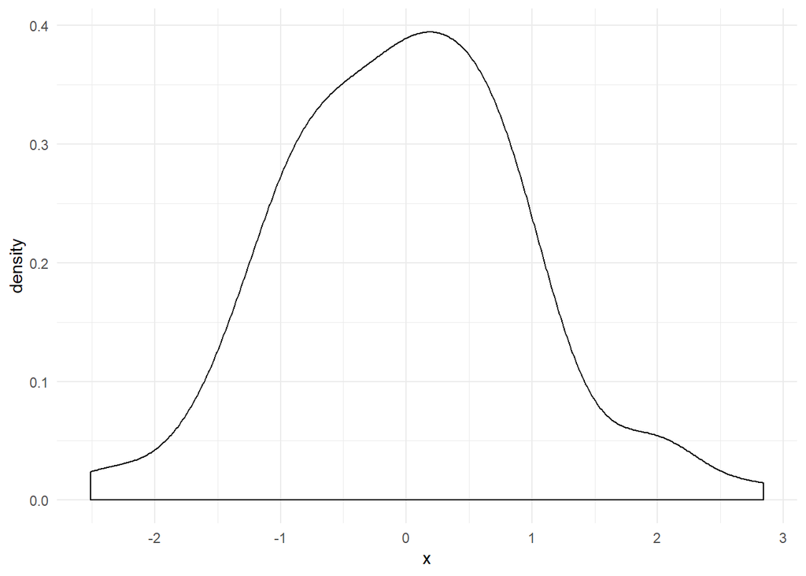

```r
#This gives a plot using x on x axis and a layer of density plot
ggplot(x_vs_y, aes(x = x)) + geom_density()
```

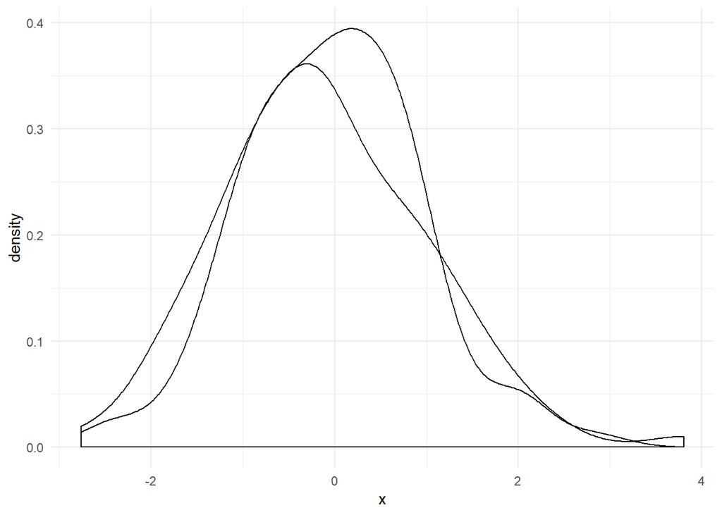

```r
#Or we can put the aes data mpping instruction in the geom itself
ggplot(x_vs_y) + geom_density(aes(x = x)) + geom_density(aes(x = y))
```

BUT the plot above doesn’t give us a legend. If we want to represent two variables like this, we need the data long so we can get a legend. This can be done by piping the data through **gather.**

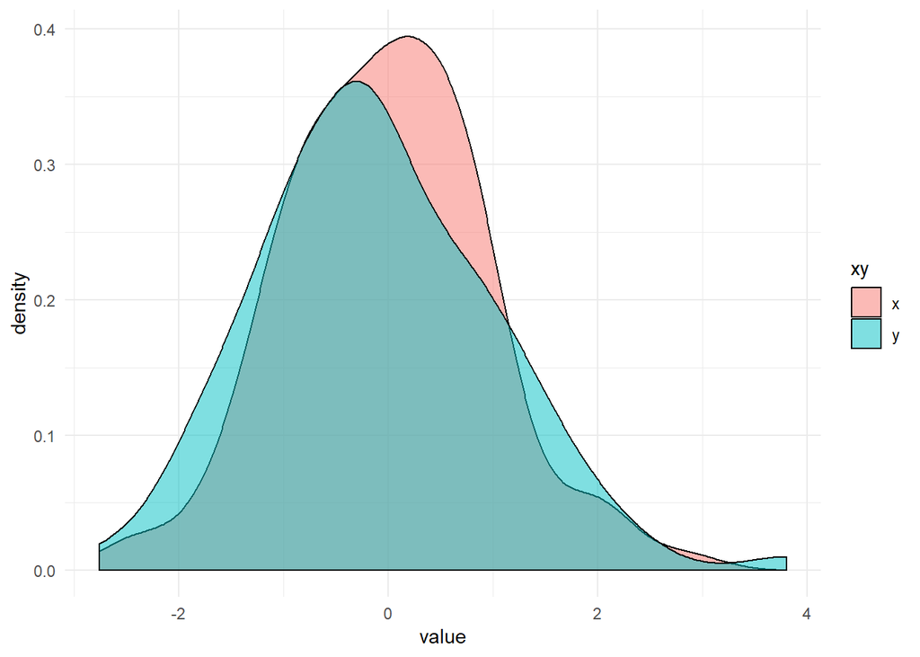

```r
#Make the data long and pipe it into ggplot, telling it the value to be plotted, with fill colour determined by the gathered identifier variable (xy)
#The alpha element in geom_desnity determines how transparent the colour is.

x_vs_y %>%
  gather(key=xy, value=value, x,y) %>%
  ggplot(aes(x = value, fill=xy)) + geom_density(alpha=.5)
```

## geom_freqpoly()

This lets you create something that’s like a density plot but is more suited to more sparse data as you can specify binwidth just like in a histogram. Below we have a histogram and freqpoly plot layered together.

Note I have also used figure presentation code in the chunk header to determine how it will look when knitted into html.

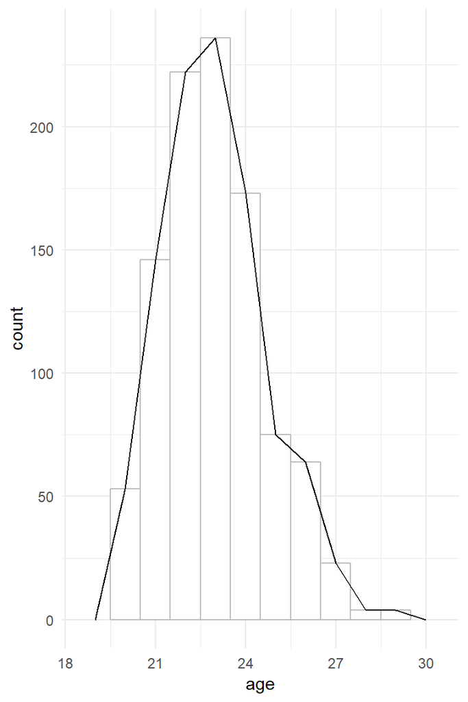

histogram plus frequency polygon

```r
ggplot(pet_happy, aes(x = age)) + geom_histogram(binwidth = 1, fill="white",color="grey") +
  geom_freqpoly(binwidth=1)
```

## geom_violin()

Violin plots are one of the best things about *GGPlot*. They show density of data on the y axis for different groups/categories on the x axis. They’re a great way to show the full range and distribution of the data, and much more informative than barcharts with error bars.

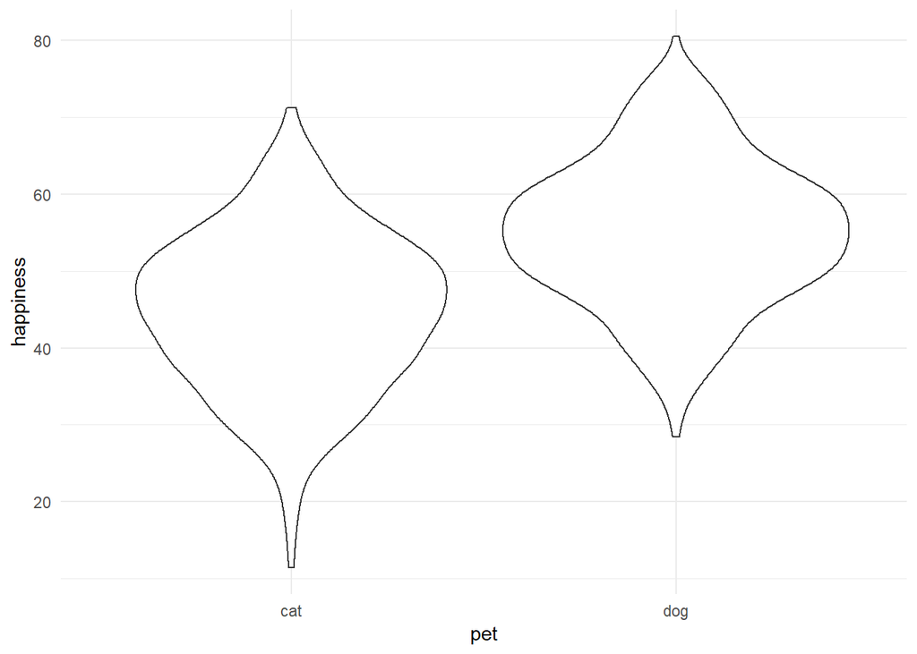

```r
#Simple violin plot
ggplot(pet_happy, aes(x = pet, y = happiness)) + geom_violin()
```

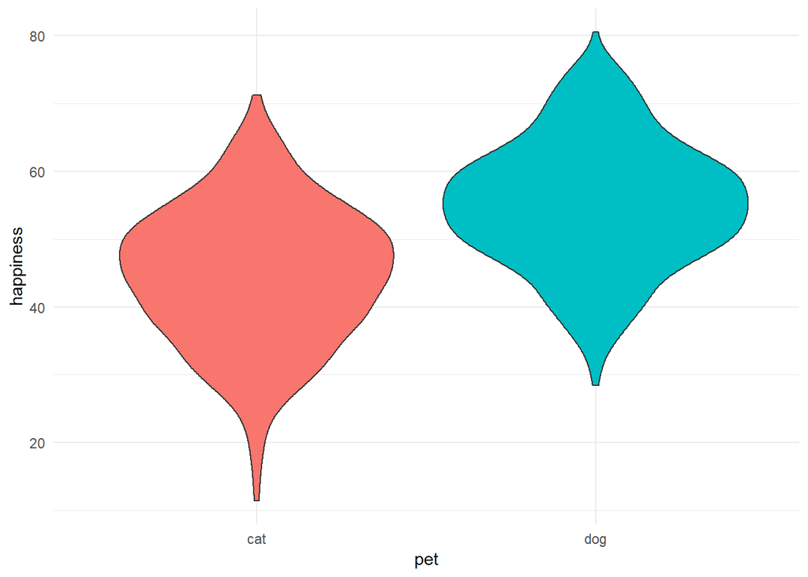

```r
#Fill colour added as in bar plots above
ggplot(pet_happy, aes(x = pet, y = happiness, fill=pet)) + geom_violin(show.legend = F)
```

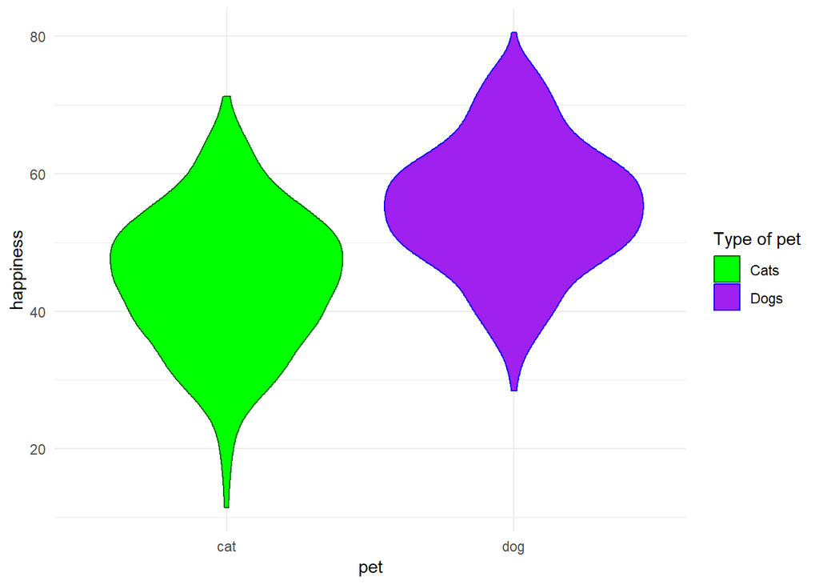

```r
#Specifying fill and line colours manually is done like this
#Note, matching labels and legend heading for the fill and line colours means they get merged into one legend.
ggplot(pet_happy, aes(x = pet, y = happiness, fill=pet, color=pet)) +
  geom_violin(show.legend = T) +
  scale_fill_manual(values=c("green","purple"), labels= c("Cats", "Dogs"), name="Type of pet")+
  scale_color_manual(values=c("darkgreen","blue"), labels= c("Cats", "Dogs"), name="Type of pet")
```

## geom_boxplot()

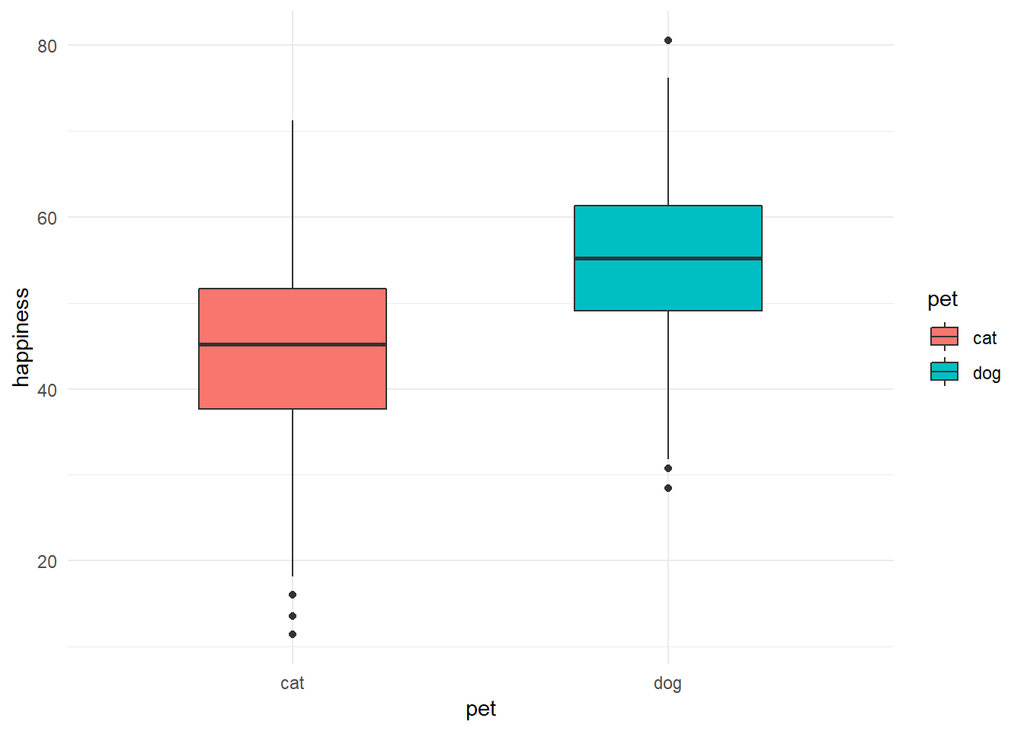

```r
#Basic boxplot with categories in different colours
ggplot(pet_happy, aes(x = pet, y = happiness, fill=pet)) +
  geom_boxplot(width=.5)
```

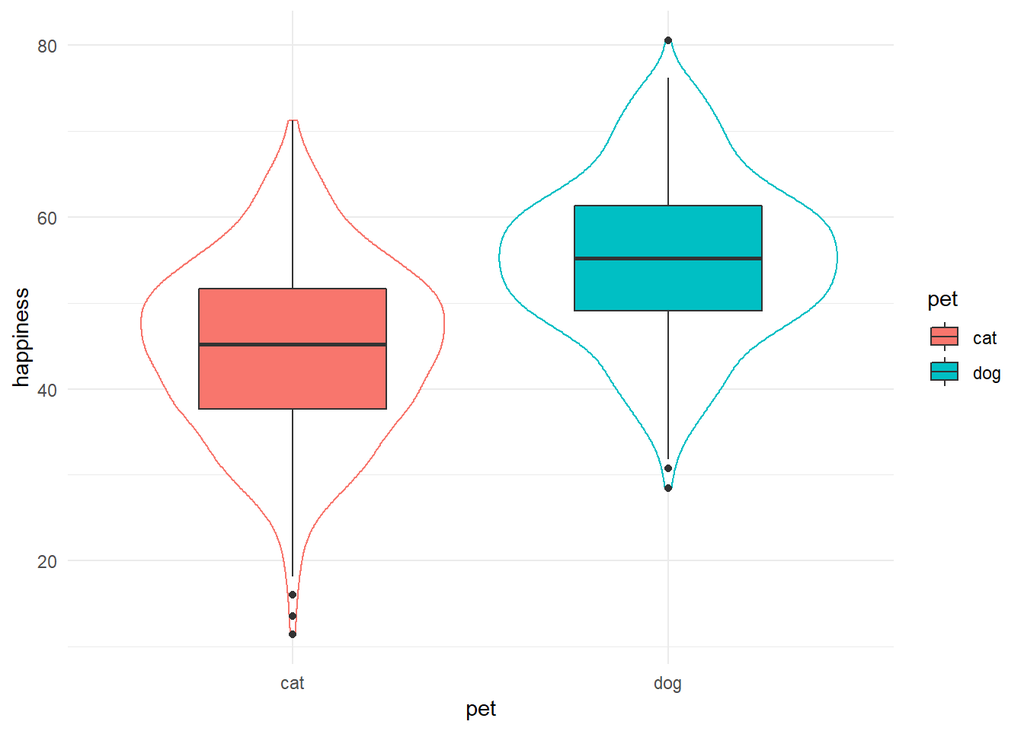

```r
#We can also put violin plots and box plots layered together.
#We will put the fill aesthetic in the boxplot  code rather than the original aes, so only boxplot has solid colour
#REMEMBER aes elements are to indicate how to use a variable in the data. Things that aren't variables (like width here) go OUTSIDE the aes().
ggplot(pet_happy, aes(x = pet, y = happiness)) +
  geom_violin(show.legend = F, aes(color = pet))+
  geom_boxplot(aes(fill=pet), width=.5)
```

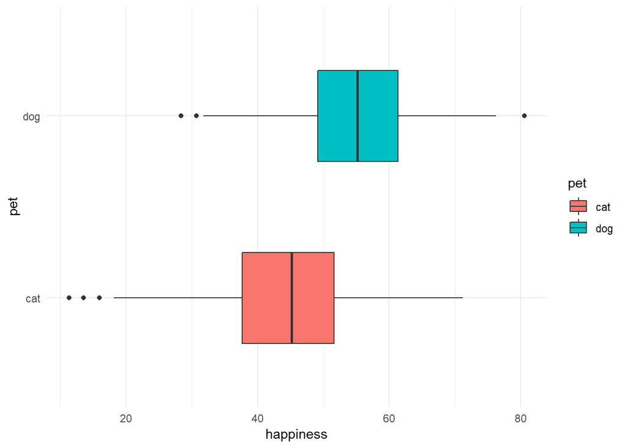

```r
#We can use coord_flip to rotate the axes 90 degrees.
ggplot(pet_happy, aes(x = pet, y = happiness, fill=pet)) +
  geom_boxplot(width=.5) +
  coord_flip()
```

## geom_col()

Violin and boxplots are among the best way to represent continuous data, But if you really *have* to use a bar chart, then **geom_col** produces bar charts based on the values given for each x axis row, in the y axis. If you want to present means, then you’ll first need to use **summarise** (and **group_by** if applicable) to calculate those means. You can then pipe the resulting values into ggplot, as in the second example below.

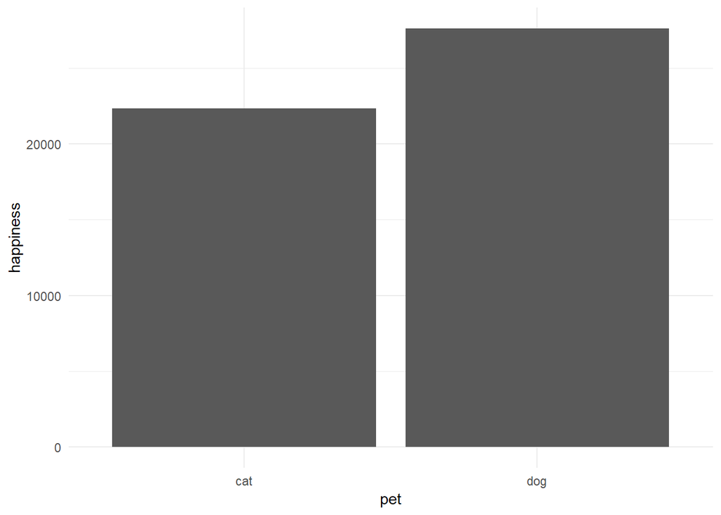

```r
#If you put your raw data in, it will simply sum the values across all the members of each categorical group like this:
ggplot(pet_happy)+geom_col(aes(x=pet, y=happiness))
```

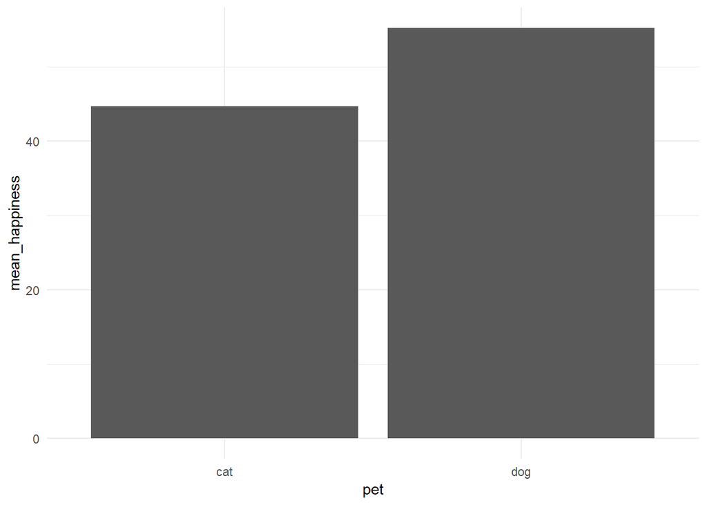

```r
#Instead, you need to pipe your data through goup by and summarise to create a new version of the dataframe with just the mean for each group like this:
pet_happy %>%
  group_by(pet) %>%
  summarise(mean_happiness=mean(happiness, na.rm = T)) %>%
  ggplot(.,aes(x=pet, y=mean_happiness)) + geom_col()
```

## Scatter and regression plots

### geom_point() (and setting labels)

Geom_point is used to produce scatterplots, with two continuous variables.

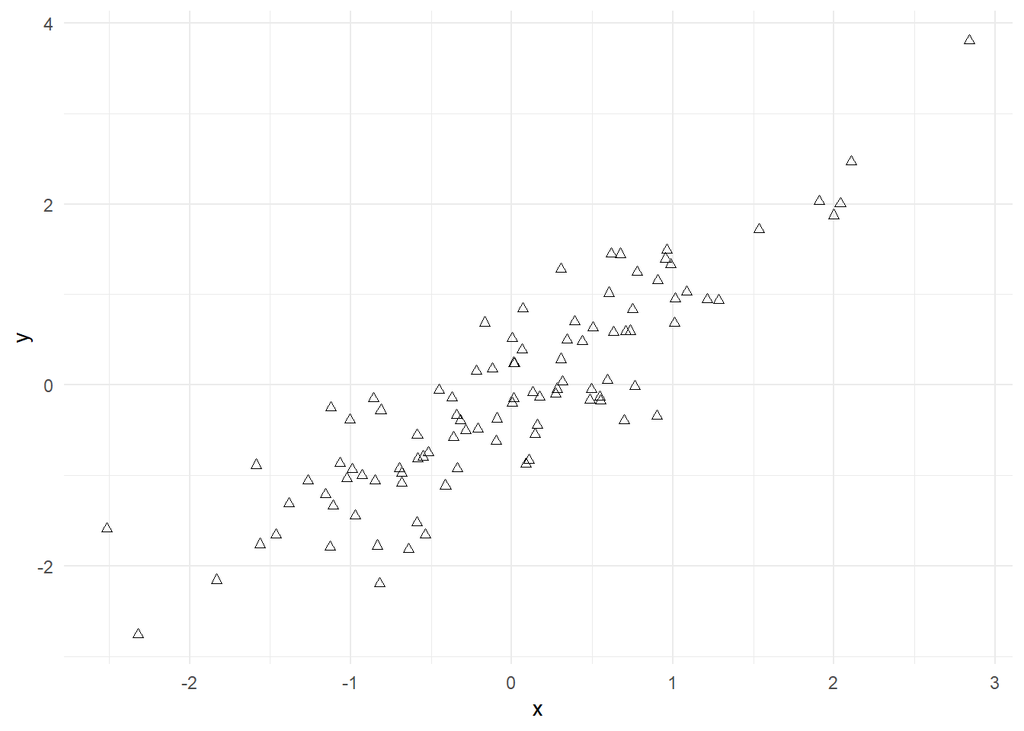

```r
#Basic scatterplot using the x/y simulated data
#Default is to use circles. You can change the shape of the points using shape - here shape #2 is a triangle
ggplot(x_vs_y, aes(x=x, y=y))+geom_point(shape=2)
```

It can be useful to manually set labels on axes. This can be done for each axis separately, or in a combined element which sets a list of labels, including title if desired.

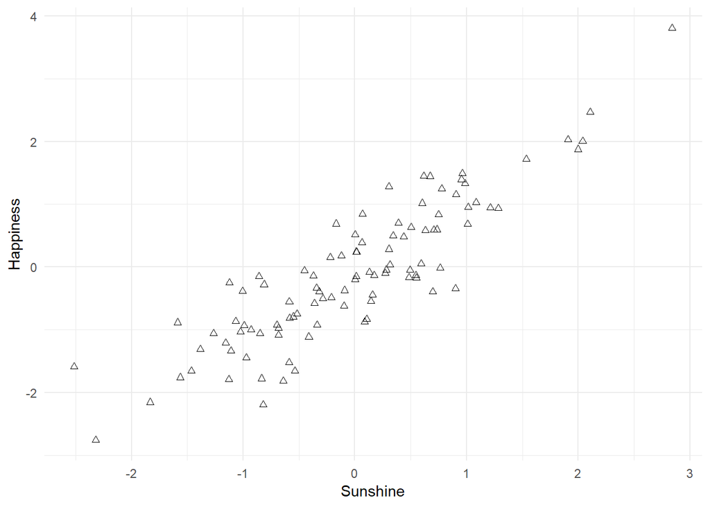

```r
#We can label our axes manually like this.
ggplot(x_vs_y, aes(x=x, y=y))+geom_point(shape=2)+
  xlab("Sunshine")+
  ylab("Happiness")
```

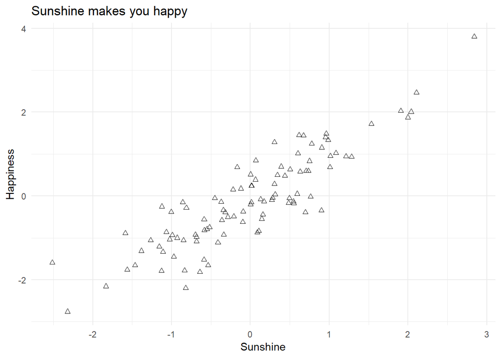

```r
#Or like this (and we can add a plot title in the same element with this one)
ggplot(x_vs_y, aes(x=x, y=y))+geom_point(shape=2)+
  labs(x= "Sunshine", y="Happiness", title="Sunshine makes you happy")
```

### geom_smooth()

This plots lines of fit between two continuous variables. It’s very flexible, we can specify what kind of line (e.g. linear regression, polynomial, with or without error shading etc). It’s particularly useful for layering over a scatterplot to illustrate regression outcomes for instance.

In the examples below we use simple linear regression (method=lm) for all plots except the first which uses loess by default.

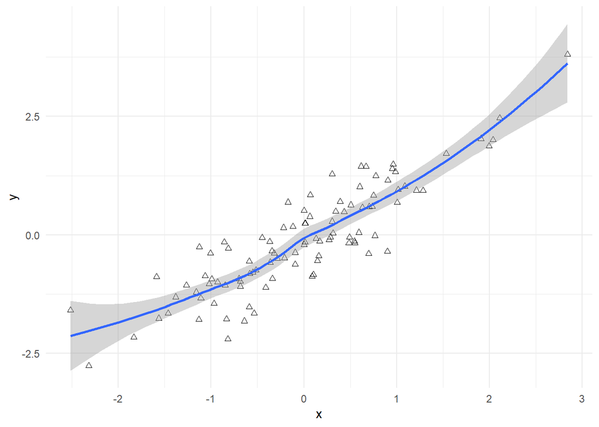

```r
#Default is to use loess fit and to include standard error range shaded
ggplot(x_vs_y, aes(x=x, y=y))+geom_point(shape=2)+
  geom_smooth()
```

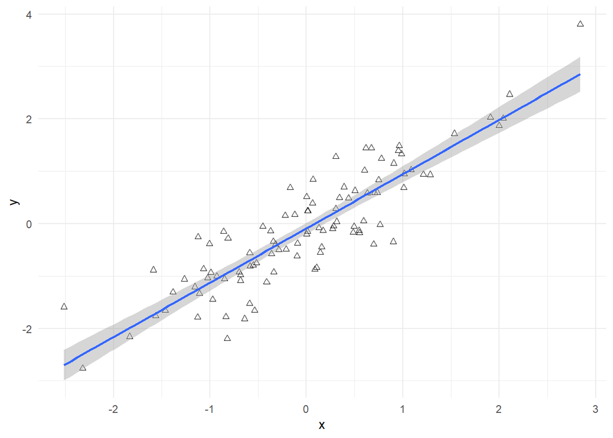

```r
#We can specify functions to fit within the element like this
ggplot(x_vs_y, aes(x=x, y=y))+geom_point(shape=2)+
  geom_smooth(method=lm)
```

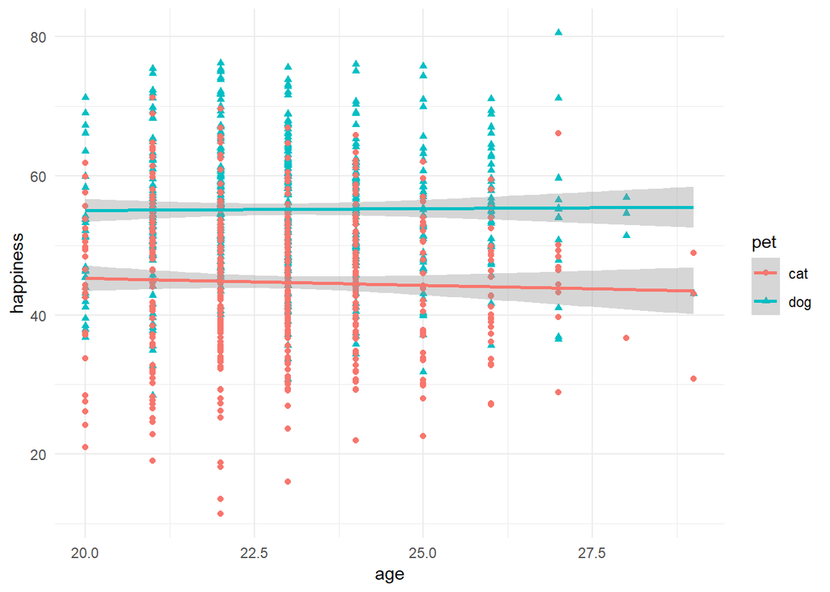

```r
#We can show both points and lines differentiated by a categorical variable like this (switching to pets data)
#We can also change shape of points by category using an aes within the points element.
ggplot(pet_happy, aes(x=age, y=happiness, color=pet))+geom_point(aes(shape=pet))+
  geom_smooth(method=lm)
```

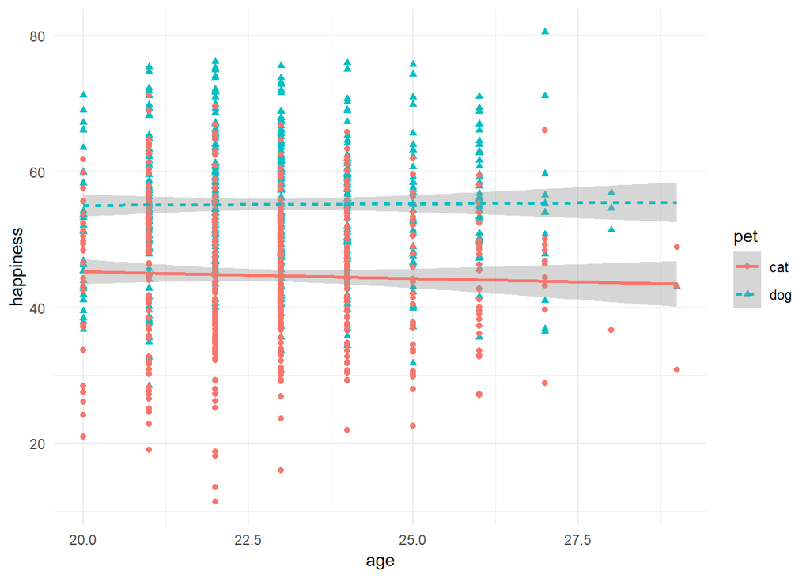

```r
#Note we don't HAVE to specify x= and y= - ggplot expects to get dataframe, x, y in that order. Then anything else has to be named.
#We can also changed linetype by category. This can also be done so that factor A determines colour, and factor B determines shape for instance.
ggplot(pet_happy, aes(age, happiness, color=pet, linetype=pet))+geom_point(aes(shape=pet))+
  geom_smooth(method=lm)
```

### Dealing with overlap

Sometimes it’s impossible to see overlapping points in big or dense datasets. Here’s some options to deal with that.

- 1. Set points large and make them transparent - this gives us darkness indicating density at that point

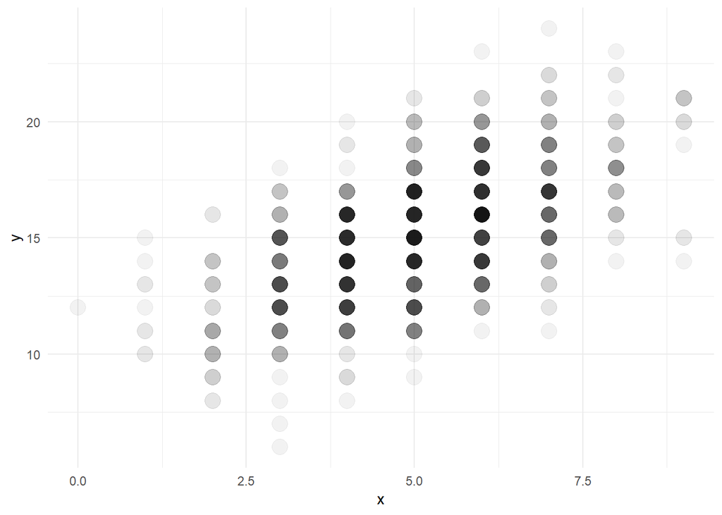

```r
ggplot(overlap, aes(x,y))+geom_point(size=5, alpha=.05)
```

- 2. Use 2-D bins to indicate density in each cell

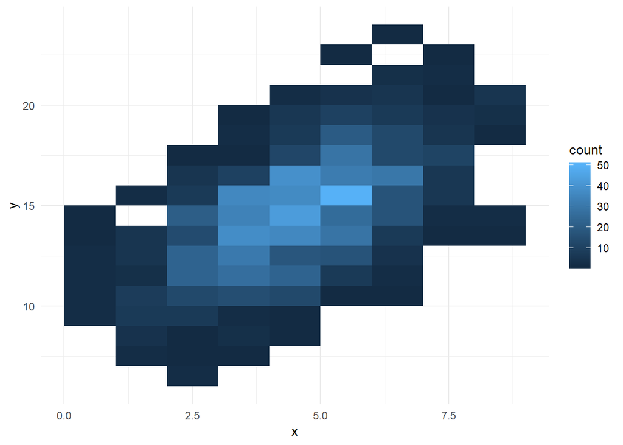

```r
ggplot(overlap, aes(x,y))+geom_bin2d(binwidth=1)
```

If we tell it not to drop empty cells, it will colour those cells with explicit zero as long as there’s at least one datapoint elsewhere in that row/column.

In the plot below we also add in a colour option called viridis-magma. This gives us a lovely heatmap with intuitive colours.

Note, that if there are zero values in a given column or row, it will simply leave them blank like this one.

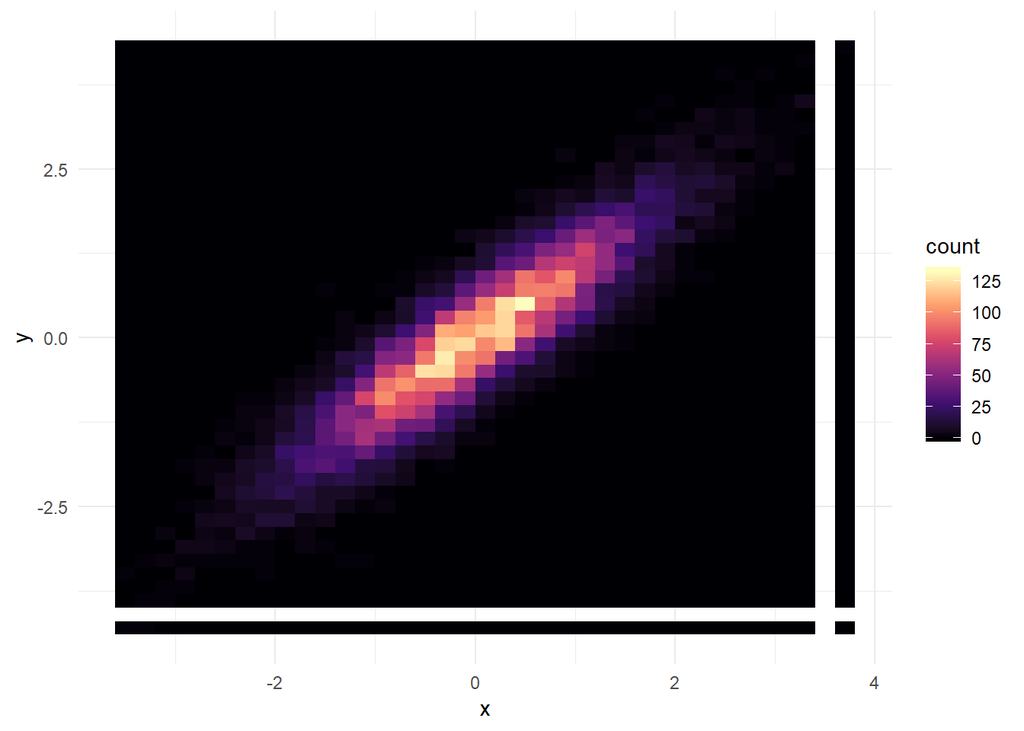

```r
ggplot(overplot, aes(x,y))+geom_bin2d(binwidth=.2, drop=F)+
  scale_fill_viridis_c(option="magma")
```

- Other options to represent overlapping data points include elements like **geom_count** where point size incicates number of cases, or for fully continuous data, **geom_density_2d** gives a topographical map of data density within the plot.

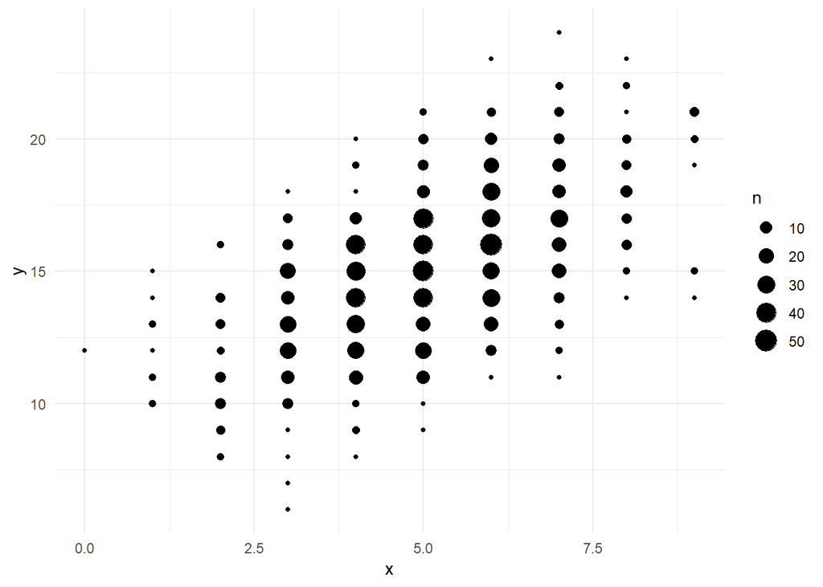

```r
ggplot(overlap, aes(x,y))+geom_count()
```

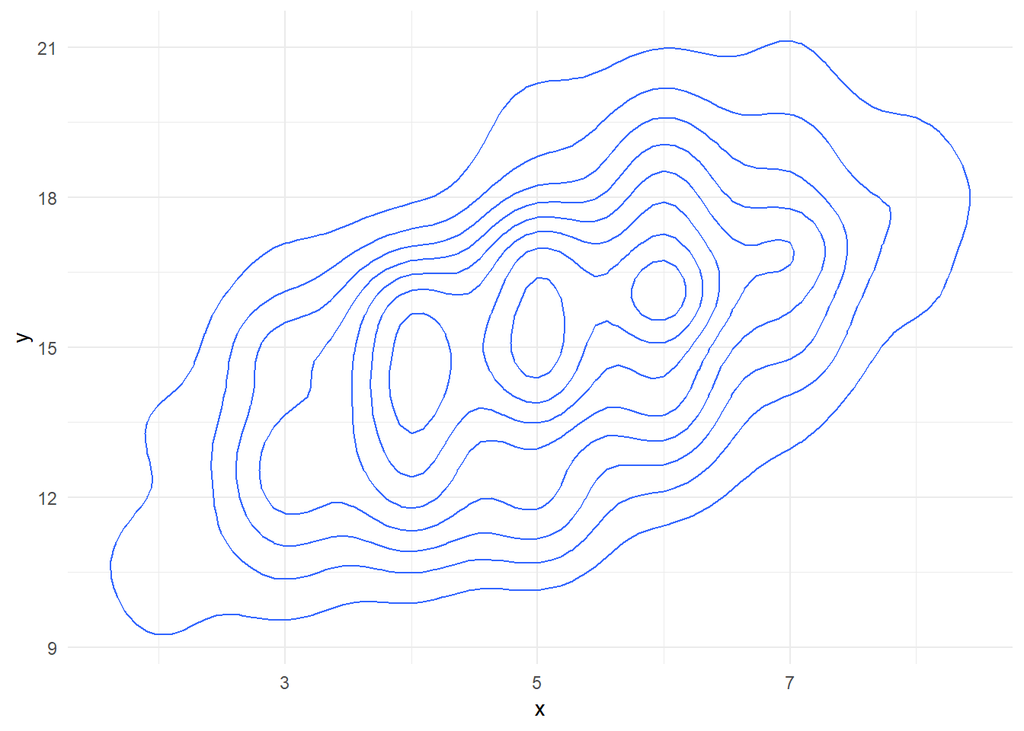

```r
ggplot(overlap, aes(x,y))+geom_density2d()
```

# Making interactive graphs for webpages

We can use the package plotly and the function ggplotly to take a ggplot object and create and interactive graph. This is particularly useful for using on webpages if you knit the document to html and then upload onto a server. It can also be used within the output below if you want to explore your data bit yourself.

The best way to do this is to assign the ggplot output to an object, just as when we work with dataframes or models. (Note this command line is hashed out for now as knitr is having trouble rendering the plot through the university network).

```r
myplot <- ggplot(pet_happy, aes(x=age, y=happiness, color=pet))+geom_point(aes(shape=pet))+
  geom_smooth(method=lm)

#plotly::ggplotly(myplot)
```

# Combining and exporting plots

We can use the *cowplot* package to do creative things with *GGPlot* objects.

```r
#First we make each individual plot
a <- ggplot(pet_happy, aes(pet, happiness, fill=pet)) + scale_fill_manual(values=c("red","blue"))
b <- a + geom_boxplot(show.legend = F)
v <- a + geom_violin(show.legend = F)
vb <- a + geom_violin(show.legend = F, fill="white") + geom_boxplot(width=.5,show.legend = F) #we overode the fill from 'a' in the violins
```

We can now combine the plots in plot_grid. It will take a best guess at layout…

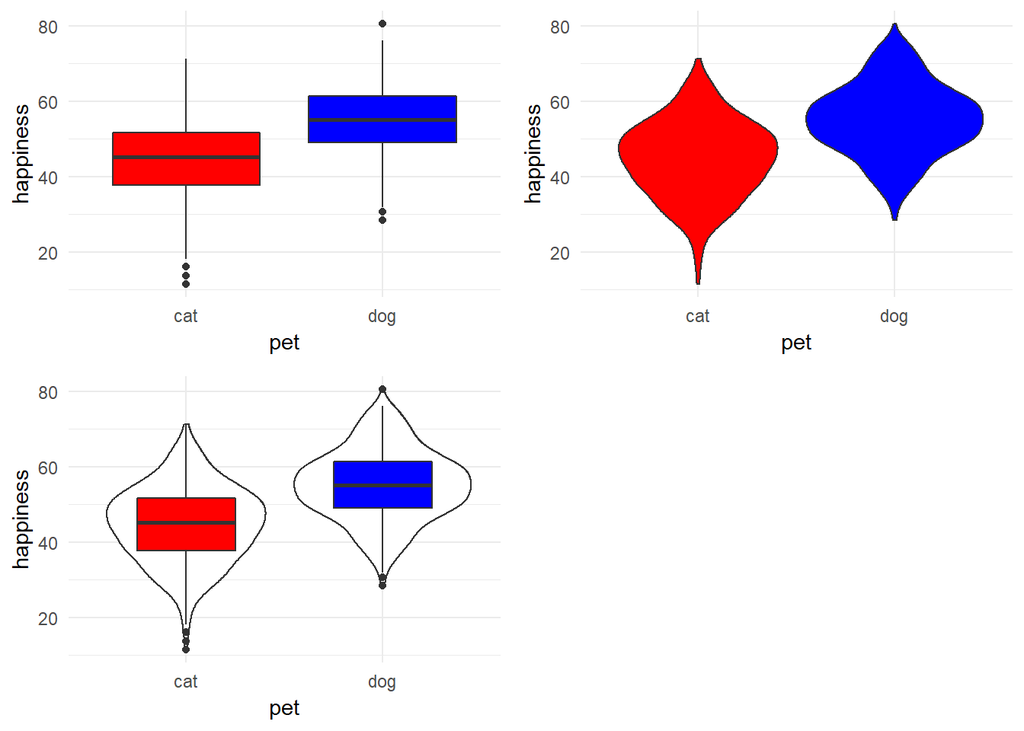

```r
cowplot::plot_grid(b,v,vb)
```

Or we can specify number of rows and/or columns…

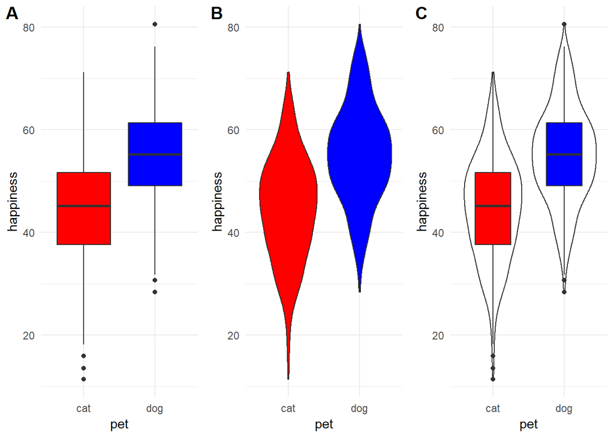

```r
cowplot::plot_grid(b,v,vb, nrow=1, labels=c("A","B","C"))
```

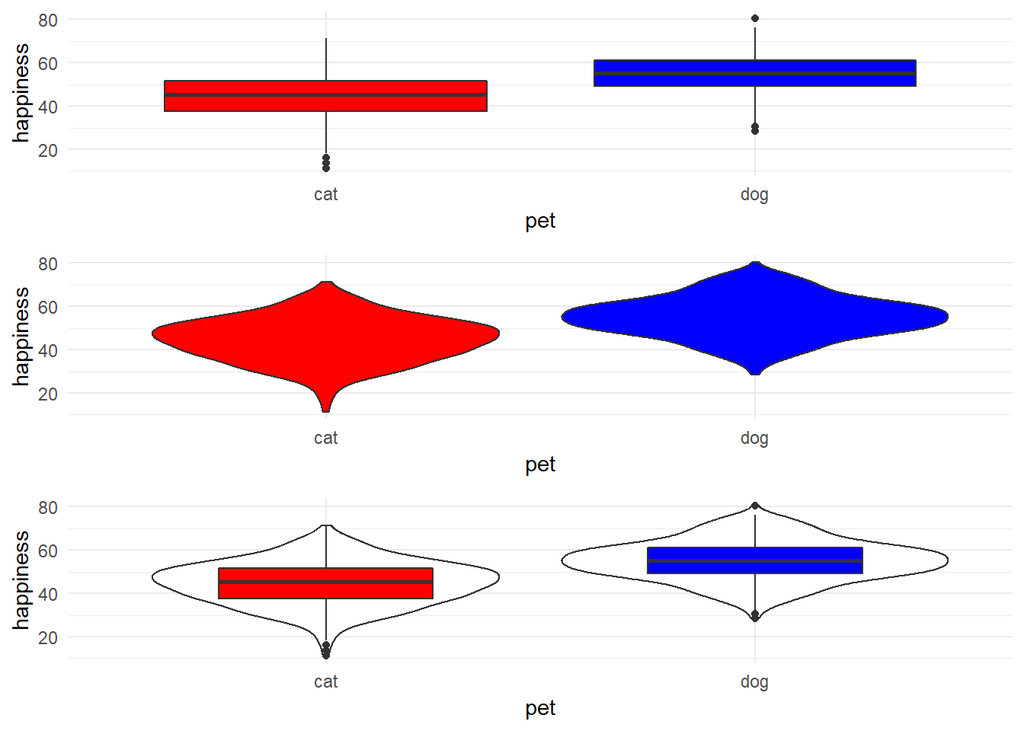

```r
cowplot::plot_grid(b,v,vb, ncol=1)
```

We can save plots using the **ggsave** function and specifying the path and image name. It can be very useful here to type the "" and then hit TAB. This will show you the contents of your current folder and lower level folders. You can then select a folder to save it if you don’t want to save the image into the same folder as your Rmd file.

By default it saves the last plot in 7.29 x 4.5 inches. However, it’s usualyl better to specify the height, width and/or resolution. For common use, best to save as jpg but for journal submissions png files give the highest quality.

```r
#Default save last image.
ggsave("images/comboplot.jpg")
#Specify that we want to save plot vb like this. We  also specify image height, weight and resolution.
ggsave("images/violinbox.png",vb, width=5, height=3, dpi=300)
```